# Experimental/ Observational Studies and Categorical Data

Day 3-4

Claire Kelling

Carleton College  
STAT 120 - Fall 2026

## Question of the Day

Do you have a favorite sport?  
Do you have a sport you find boring?

## Today’s Topics

Logistics:

- Homework 1 and AI Agreement due tonight!
- Be sure to join Slack!
- Matching pages on Gradescope
- Statistician of the Week!

Topics covered today **and Monday:**

- Continue introducing R/RStudio
- Using R Markdown (how to knit, produce code chunks, headers)
- Experiments and Observational Studies
- Categorical Data
- Working with categorical data in R

# R Markdown

## How to run code

[figure not shown]

- Code needs to be run **in order**
- You can also run individual lines by using *Ctrl + Enter*

## How to insert a code “chunk”

[figure not shown]

- For templates, there will already be code chunks
- Eventually you will start building your own Markdown documents!

## How to “knit” your document

[figure not shown]

- You need to test your code **as you go** or you run the risk of having errors when you knit the document
- Knit to a pdf for submission to Gradescope

## More Resources on R

- [Introduction to R Slides](https://maxkasy.github.io/home/files/teaching/TopicsEconometrics2019/IntroductiontoR-Slides.pdf)
- [Introduction to R pdf](https://monashbioinformaticsplatform.github.io/r-intro/r-intro.pdf)
  - Starting out
  - Matrices, dataframes
  - ggplot
- [Intro to R Video](https://www.youtube.com/watch?v=BvKETZ6kr9Q&t=7s)
  - A little skippy, but a great resource!

## Getting Help with R

**Note:** Save a reproducible record of your work.

All relevant code goes in your script. For example, don’t use the “import data” dropdown menu (unless you then copy the code into your script).

- Lab manual
- R help file (type, e.g., ?barplot)
- Math/Stats Skills Center assistants
- Slack
- Office Hours
- Google
- AI tools? (debugging!)

# Experimental and Observational Studies (Sect 1.3)

## Recap

**Previously**: What’s the population?

- Is the sample representative?

**Now**: relationships between variables

- Is an association *causal*?

## Central concepts:

- **Association**: values tend to vary together
  - If I know X, does that give me information about Y?
- **Causation**: changing $X$ tends to influence $Y$
  - Did $Y$ change *because* $X$ changed?

## Association

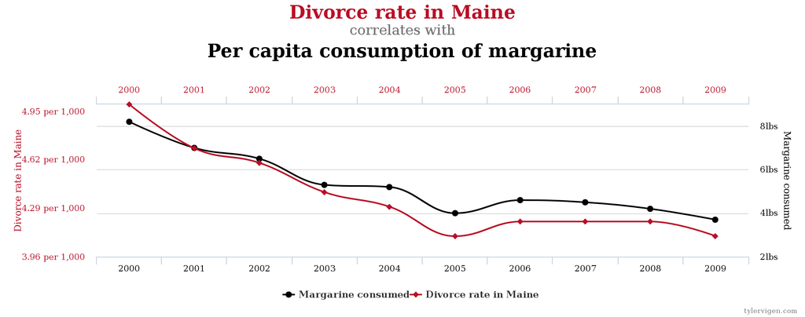

## Causation

[figure not shown]

## Confounding variables

Causation *cannot* be determined if confounders are unaccounted for.

**Confounder:** a variable that *causes* both $X$ and $Y$

**Examples of associations**:

- Ice cream sales / drowning deaths
  - *heat* causes people to eat ice cream and go swimming
- Sleeping with shoes on / having a headache in the morning
  - both are caused by *drinking too much*
- Smoking / lung cancer
  - True, but R. A. Fisher thought *genetics* may be a confounder

## Explanatory and Response Variable

- An **explanatory variable** *(x, independent variable)* is used to predict or explain the values of a **response variable** *(y, dependent variable)*

## Explanatory and Response Variables?

What are the explanatory and response variables?

- Google randomizes a banner ad placement and observes whether you click on it
  - X: Banner ad placement, Y: Click (yes/no)
- Six cities with different typical fine particulate concentrations are chosen and we measure their average asthma rates
  - X: Particulate concentration, Y: Average asthma rates
- Several farmers planting either varietal 1 or 2 are surveyed and we measure their average yields
  - X: Corn varietal, Y: Average yield
- Several seeds of two varietals of corn are randomly assigned to be planted in subplots (the subplots are the cases/observations) of a field and we then measure the average yield for each varietal
  - X: Corn varietal, Y: Average yield

## Experiments vs. Observational Studies

- **Experiment**: researcher manipulates explanatory variables (treatments)
- **Observational Study**: researcher does not manipulate any variables

*It is very difficult to control for confounders in observational studies*

## Experiment or Observational Study?

Your turn: An experiment or an observational study?

1. Google randomizes a banner ad placement and observes whether you click on it
2. Six cities with different typical fine particulate concentrations are chosen and we measure their average asthma rates
3. Several farmers planting either varietal 1 or 2 are surveyed and we measure their average yields
4. Several seeds of two varietals of corn are randomly assigned to be planted in subplots (the subplots are the cases/observations) of a field and we then measure the average yield for each varietal

## Experiment or Observational Study?

An experiment or an observational study?

- Google randomizes a banner ad placement and observes whether you click on it
  - Experiment
- Six cities with different typical fine particulate concentrations are chosen and we measure their average asthma rates
  - Observational study
- Several farmers planting either varietal 1 or 2 are surveyed and we measure their average yields
  - Observational study
- Several seeds of two varietals of corn are randomly assigned to be planted in subplots (the subplots are the cases/observations) of a field and we then measure the average yield for each varietal
  - Experiment

## How Experiments Can Reduce Confounding

**Idea**: We can manipulate treatment variable so it is **unassociated with confounders.**

**How?**

- *Randomize* their assignments!
- Each case is equally likely to get any treatment value, so the treatment won’t be associated with pre-treatment measurements (in particular, not caused by external factors)

Can then compare the treatment to a **control group**, usually a “null treatment”/placebo.

## Knee Surgery for Arthritis

In a knee surgery study, those in the control group received a fake knee surgery. They were put under and cut open, but the doctor did not actually perform the surgery. All of these patients also reported less pain!

- The improvement was indistinguishable between those receiving the real surgery and those receiving the fake surgery!
- **Why??**

Source: “The Placebo Prescription,” NY Times Magazine, 1/9/00.

## Placebos

- **Placebo effect:** People can experience the effect they think they should be experiencing, even if they aren’t actually receiving the treatment
- Control groups are often given a placebo, a fake treatment that resembles the active treatment as much as possible
- If possible, randomized experiments should be **double-blinded**: neither the participants *or* the researchers evaluating participants should know which treatment the participants are actually getting

## Role of Randomization

- in *sampling*: create a representative sample (cases)
- in *experiments*: reduce confounding (variables)

## Further notes on causality

“causal” $\ne$ “deterministic”

- “Smoking causes lung cancer”: smoking increases the risk of lung cancer, but there is individual variability
- “Disneyland causes cancer”?

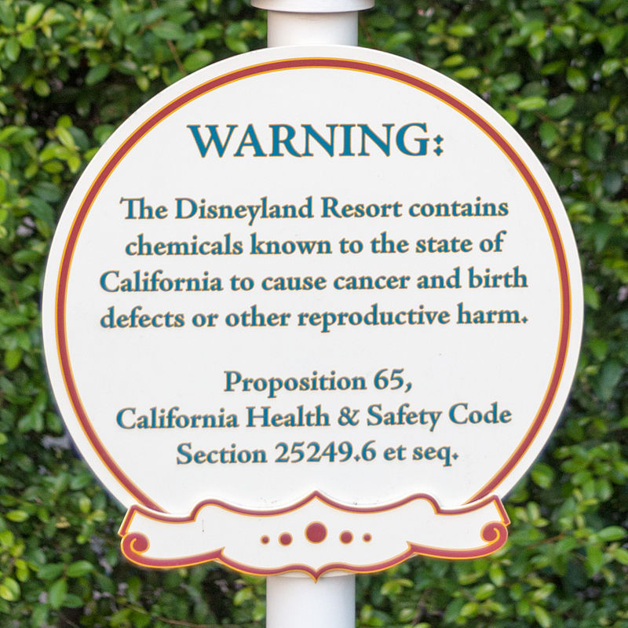

The *effect size* and the *variability* are important, even if a causal relationship has been established

## Two Types of Randomized Experiments

**Randomized comparative**: randomly assign treatments to subjects

- eg. polio vaccine

**Matched Pairs**: each subject gets both treatments, in random order

- Not always possible
- All comparisons can be made within subject (reduces confounding)

## Goals of the study matter

- If the focus of the study is using a sample to **estimate a population parameter**, you need a random sample but do not need a randomized experiment (example: election polling)
- If the focus of the study is **establishing causality**, you need a randomized experiment and can settle for a nonrandom sample (example: drug testing)
  - Still need to consider how/if we can generalize to a larger group!

# Summary

## Chapter 1 Summary

Was my sample randomly selected from the population?

- **no**: usually not representative of population
- **yes**: usually representative of population

In my sample, A and B are associated. Does A cause B? My data is from

- **an observational study**: difficult to establish causality, due to confounding
- **an experiment**: may be possible to establish causality

I did an experiment. Did I randomize the treatment allocations?

- **no**: difficult to establish causality, due to confounding
- **yes**: possible to establish causality

## Next Up

Working with data

- More on data types (first up: categorical data)
- Using R/RStudio

# Descriptive Statistics

## Descriptive Statistics (Chapter 2)

- In order to make sense of data, we need ways to summarize and visualize it
- Summarizing and visualizing variables and relationships between two variables is often known as descriptive statistics, also known as exploratory data analysis (EDA)
- The type of summary statistics and visualization methods to use depends on the **type of variable(s)** being analyzed (categorical or quantitative).

## Describing Categorical Data

**Numerically**

- Counts (frequencies), percentages/proportions (relative frequencies)
- $p$ = proportion for a **population** (parameter)
- $\hat{p}$ = proportion for a **sample** (statistic) (“p-hat”)

$$\text{prop} = \frac{\text{Number in that category}}{\text{Total number}}$$

**Graphically**

- Bar chart

## Describing Categorical Data

- The **distribution** of categorical variable “Y” describes the count or percent of observations that fall into each category of variable “Y”.
- E.g. In a survey of Little Joy visitors, 78% prefer coffee, 22% prefer tea.

## Two Categorical Variables: Two-Way Tables

**Make our own two-way table**

- Introvert vs Extrovert
- Cat vs Dog

|  | Introvert | Extrovert | Total |
| --- | --- | --- | --- |
| Cat | 3 | 6 | 9 |
| Dog | 15 | 6 | 21 |
| Total | 18 | 12 | 30 |

- What percentage of the class are introverts?
- What percentage of the class are introverts AND prefer dogs?
- **(Question:** Will being an extrovert impact your pet preference?)

## Questions for Categorical Variables

Are people who are introverts vs extroverts (primarily) different in terms of their pet preference?

- Difficult to determine from the table if there is a relationship between these two categorical variables
- Can use **conditional proportions** or **bar charts** to explore this in more detail

## Joint Distribution

Overall table of proportions: (**joint** distribution)

- All entries sum to 1
- What percentage of the class are introverts AND prefer dogs?

|  | Introvert | Extrovert |
| --- | --- | --- |
| Cat | 0.1 | 0.2 |
| Dog | 0.5 | 0.2 |

## Conditional Distribution

Conditional table of proportions: (**conditional** distribution)

- Columns sum to 1 (could also make the rows sum to 1)
- Is the proportion of those who prefer dogs higher for one social preference category than for the other?

|  | Introvert | Extrovert |
| --- | --- | --- |
| Cat | 0.17 | 0.5 |
| Dog | 0.83 | 0.5 |

## Bar Chart (based on counts)

Question:

- Do people tend to be introverts or extroverts? Do they prefer cats or dogs?
- Is the proportion of those who prefer dogs higher for one social preference category than for the other?
- (Dark is Cat preference)

Counts:

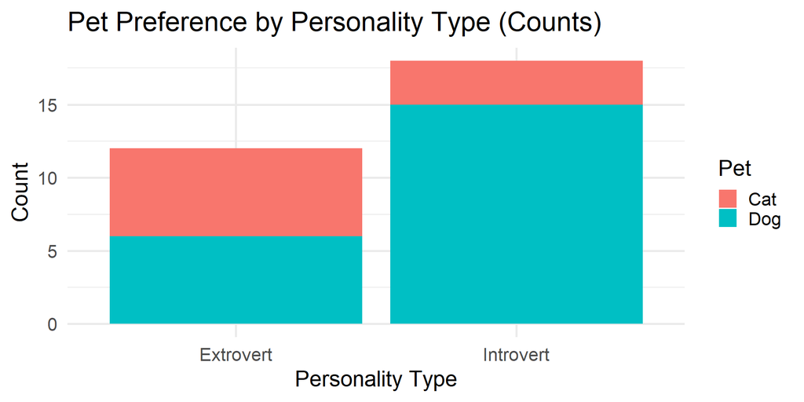

## Stacked Bar Chart (based on proportions)

Question:

- Do people tend to be introverts or extroverts? Do they prefer cats or dogs?
- Is the proportion of those who prefer dogs higher for one social preference category than for the other?
- (Dark is Cat preference)

Proportions:

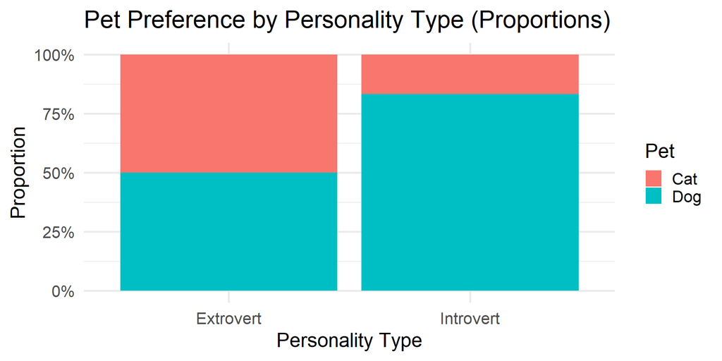

## Note: What happens if I flip x and y?

The $y$ (dependent) variable should always be the color.

If we flip $x$ (independent) and $y$ (independent) so that we color by $x$ and have $y$ on the horizontal axis, we can still tell if $x$ and $y$ are dependent, but cannot ask the question “**how does x impact y?**”

## Proportions and Bar Charts in R

**Starting Point:** Dataset of individuals (data) and categorical variables on these individuals (cat1 and cat2)

**1.)** Using the dataframe, create a contingency table of counts

```r
count_tab <- table(data$cat1, data$cat2)
```

**2.)** Using the *counts*, create a table of proportions

```r
#proportion of total
prop_tab <- proportions(count_tab)
#rows total to 1
prop_tab <- proportions(count_tab, margin =1)
#columns total to 1
prop_tab <- proportions(count_tab, margin =2)
```

**3.)** Plot a stacked bar plot *using original dataset*

```r
ggplot(data, aes(x = cat1, fill = cat2)) +
   geom_bar(position = "fill")
```

## Example: Flowers v. Mississippi

- 2019 Supreme Court case:
  - Has Mississippi prosecutor Doug Evans deliberately use “peremptory challenges” to strike black jurors from jury pools?
- American Public Media journalist collected trial data from this district from 1992 to 2017
  - https://github.com/APM-Reports/jury-data
- The data set APM_DougEvansCases.csv contains data on 1517 jurors for cases which listed Doug Evans as the first prosecutor.
  - Only looking at jurors with race listed as Black or White.
  - These jurors are eligible for Evans to strike.

## (1a) Inspect your data

Read in the data

```r
jurors <- read.csv("https://www.math.carleton.edu/ckelling/intro_data/APM_DougEvansCases.csv")
dim(jurors)
```

```
[1] 1517    6
```

What does *dim* tell us?

## (1a) Inspect your data

Look at the first **two rows** of the data set

```r
library(dplyr) # load the dplyr library
slice(jurors, 1,2)
```

```
  trial__id  race        struck_state defendant_race      same_race
1         4 Black Not struck by State          White different race
2         4 Black     Struck by State          White different race
                      struck_by
1 Juror chosen to serve on jury
2           Struck by the state
```

*slice* is a function only available in the **dplyr** R package

## (1a) Inspect your data

Look at the first 10 entries in the struck_state variable.

```r
jurors$struck_state[1:10]
```

```
 [1] "Not struck by State" "Struck by State"     "Not struck by State"
 [4] "Not struck by State" "Struck by State"     "Not struck by State"
 [7] "Struck by State"     "Not struck by State" "Not struck by State"
[10] "Not struck by State"
```

`data$variable` pulls one variable column from the data frame

## (1b) Numeric summaries: counts

```r
counts <- table(jurors$struck_state)
counts
```

```
Not struck by State     Struck by State
               1084                 433
```

- `table` gives counts of whether the state struck a juror
- “`counts <-`” is used to store the output of `table` in an object called `counts`

## (1b) Numeric summaries: proportions

What proportion of eligible jurors were struck by the state from the jury pool?

```r
proportions(counts)
```

```
Not struck by State     Struck by State
          0.7145682           0.2854318
```

`proportions` turns `table` counts into proportions

## (1c) Graphical summary: bar plot

- barplot gives a simple bar plot of the struck by state counts, using the counts table summary as input:
- ylab = “count” makes the y-axis label say “count”

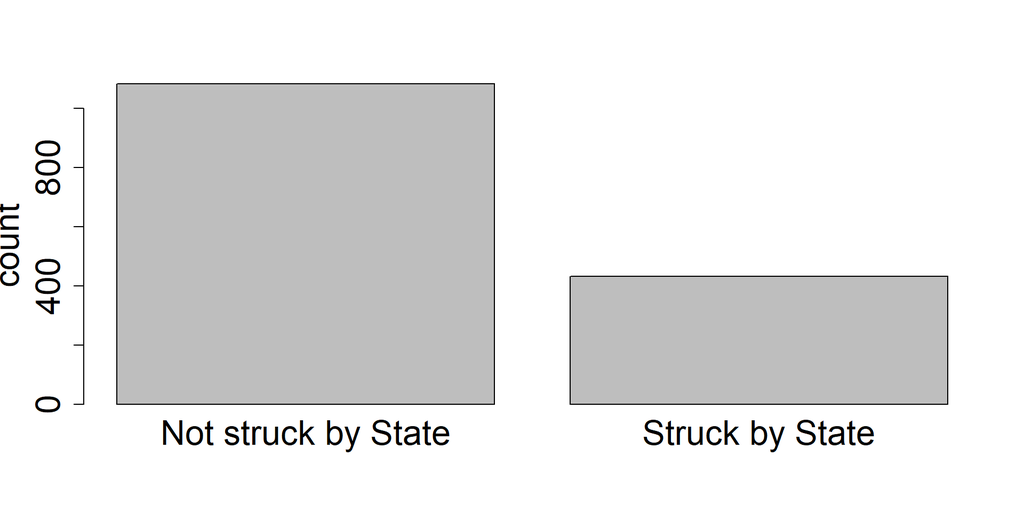

```r
barplot(counts, ylab = "count")
```

## Associations between two categorical variables

How are race and state strikes associated?

How does state struck status vary by juror race?

**Numerically:**

- Summarize **counts** in a contingency/two-way table
- The **conditional distribution** of “Y” given “X” describes how Y is distributed within each category of X (grouped by X).
- e.g. In the 2016 election, 45% of white college grads voted for Clinton and 49% voted for Trump. Of white non-college grads, 28% voted for Clinton and 67% voted for Trump.

## (1d) Two-way (contingency) table

How many jurors were white and were not struck by the state?

```r
mytable <- table(jurors$race, jurors$struck_state)
mytable
```

```
        Not struck by State Struck by State
  Black                 225             310
  White                 859             123
```

*table()* gives two-way tables when two variables are included

## (1e) Conditional proportions

proportions gives conditional proportions grouped by the row variable when margin=1

```r
proportions(mytable, margin = 1)
```

```
        Not struck by State Struck by State
  Black           0.4205607       0.5794393
  White           0.8747454       0.1252546
```

- What proportion of eligible black jurors were struck by the state?
- Of all eligible black jurors, about 57.9% were struck by the state.
- What proportion of eligible white jurors were struck by the state?
- Of all eligible white jurors, about 12.5% were struck by the state.

## (1e) Conditional proportions

Is there evidence of an association between juror race and state strikes?

```r
proportions(mytable, margin = 1)
```

```
        Not struck by State Struck by State
  Black           0.4205607       0.5794393
  White           0.8747454       0.1252546
```

Yes, there is an association because the rate of state strikes varies greatly by juror race with about 60% of black jurors struck compared to only 13% of white jurors.

## Associations between two categorical variables

**Graphically:**

- stacked bar graph of conditional proportions
  - x-axis: conditioning (explanatory) variable
  - y-axis: response proportions

## (1f) Stacked bar graph

We can graph a conditional distribution using the ggplot2 graphing package.

```r
library(ggplot2) #load package
```

The basic syntax for our stacked bar graph is

```r
ggplot(mydata, aes(x = x, fill = y)) +
        geom_bar(position = "fill")
```

- aes graph “aesthetics”: map a variable to some visual aspect of the graph
- geom_bar graph geometry: describes the form of graph
  - position: describes how to draw the bar graph

## (1f) Stacked bar graph

Conditional distribution of strike status by juror race:

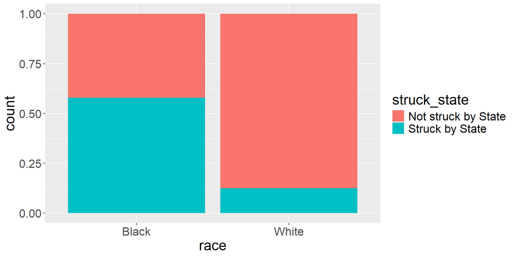

```r
ggplot(jurors, aes(x = race, fill = struck_state)) +
        geom_bar(position = "fill")
```

## (1f) Stacked bar graph

We can add more “layers” to the graph with the + sign:

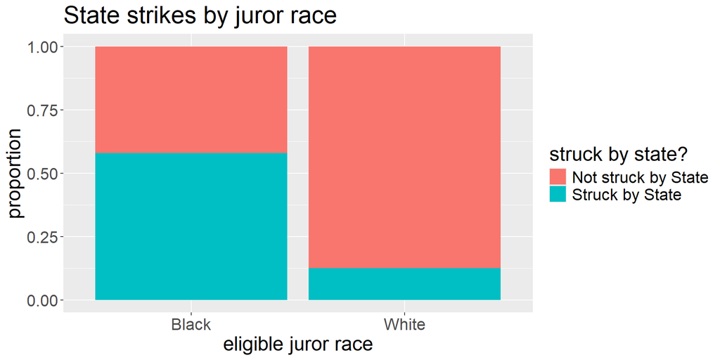

```r
ggplot(jurors, aes(x = race, fill = struck_state)) +
        geom_bar(position = "fill") +
        labs(title = "State strikes by juror race", y = "proportion",
             x = "eligible juror race", fill = "struck by state?")
```

## Independence

What would the stacked bar chart look like if variables were independent?

- Two categorical variables are independent if the conditional proportions all equal the marginal proportions
  - **Marginal:** Distribution of one variable (struck by state)
  - **Conditional:** Distribution of one variable, based on another (struck by state, given juror race)
  - i.e., proportions for variable 1 don’t depend on variable 2

## Next up:

Exploratory Data Analysis (EDA) for Quantitative Variables